# Mesures pêches électriques

# 1 Contexte et données

Afin d’objectiver les conditions dans lesquelles se déroulent les opérations de terrain ainsi que les réglages des appareils, des mesures ont été réalisées à l’occasion de pêches à l’électricité sur les cours d’eau de Bretagne et des Pays-de-la-Loire au cours des années 2016 à 2021. Ces opérations ont toutes été menées “en régie” par l’ex-AFB puis par l’OFB.

## 1.1 Caractéristiques des stations pêchées

| Station | Dépt | Type de pêche | Anodes | Distance anode cathode | Largeur moyenne | Largeur mesure | Profondeur moyenne | Profondeur mesure |
| --- | --- | --- | --- | --- | --- | --- | --- | --- |
| Loup a Plougonver | 22 | Inv | 2 |  |  |  |  |  |
| Milin Prat à Loguivy Plougras | 22 | Inv | 1 | 45 | 2.52 | 16 | 2.5 | 15 |
| Trieux à Plesidy | 22 | Inv | 2 | 130 | 6.2 | 16 | 6.5 | 20 |
| Leguer à Ploubezre | 22 | EPA pied | 1 | 250 | 16.57 | 46 | 17.5 | 75 |
| Lié à la Prenessaye | 22 | EPA pied | 1 | 70 | 9.14 | 23 | 8 | 25 |
| Aulne à Locmaria Berrien | 29 | EPA pied | 1 | 320 | 13.29 | 44 | 8.5 | 35 |
| Elorn à Commana | 29 | Inv | 1 | 20 | 2.86 | 21 | 3.1 | 15 |
| Isole à Saint Thurien | 29 | EPA pied | 1 | 110 | 13.2 | 33 | 12.4 | 30 |
| Pont l'abbé à Peumerit | 29 | Inv | 2 | 140 | 4.5 | 19 | 5.3 | 12 |
| Kerambellec à Brasparts | 29 | Inv | 1 | 30 | 2.97 | 19 | 3.15 | 15 |

[output cut: 33 more lines]

## 1.2 Les paramètres mesurés

Ces paramètres, mesurés pour chaque pêche, reflètent :

- Des caractéristiques du milieu (conductivité de l’eau en $\mu S/cm$, température de l’eau en °C)
- Le réglage de l’appareillage (Choix du cran sur le “Héron”)
- La résultante de l’interaction entre le milieu et l’appareil de pêche :
  - Le champ créé par l’appareil sur le milieu, mesuré au moyen d’une sonde “Penny” placée à 1 ou 1,5m de la cathode et exprimé en V.m<sup>-1</sup>
  - Les paramètres du courant électriques délivré (tension en V, intensité en A et puissance en kW)

Tableau des données brutes :

| Station | Année | Cran | Conductivité | Température | Voltage | Puissance | Intensité | Penny à 1m du centre | Penny à 1,5m du centre | Penny à 1,5m du bord |
| --- | --- | --- | --- | --- | --- | --- | --- | --- | --- | --- |
| Loup a Plougonver | 2021 | 4 | 110 | 16 | 465 | 1.2 | 2.58 | 1.4 |  |  |
| Milin Prat à Loguivy Plougras | 2021 | 3 | 180 | 17.7 | 316 | 0.62 | 1.96 | 1.3 |  |  |
| Trieux à Plesidy | 2021 |  | 220 | 18.8 | 440 | 2.06 | 4.68 | 1.2 | 0.8 |  |
| Leguer à Ploubezre | 2021 | 3 | 220 | 18.8 | 315 | 1 | 3.17 | 1.2 | 0.8 |  |
| Lié à la Prenessaye | 2021 |  | 190 | 13.4 |  |  |  | 2.34 | 1.8 |  |
| Aulne à Locmaria Berrien | 2021 | 4 | 160 | 13.5 | 450 | 0.8 | 1.78 | 1.45 | 0.9 |  |
| Elorn à Commana | 2021 | 4 | 60 | 13.3 | 457 | 0.47 | 1.03 | 2.8 | 1.7 |  |
| Isole à Saint Thurien | 2021 |  |  |  |  |  |  |  |  |  |
| Pont l'abbé à Peumerit | 2021 |  |  |  |  |  |  |  |  |  |
| Kerambellec à Brasparts | 2021 | 3 | 170 | 11.5 | 300 | 0.4 | 1.33 | 1.1 | 0.6 |  |

[output cut: 212 more lines]

# 2 Distribution des variables

On peut dans un premier temps examiner les valeurs prises par chacune des colonnes des tableaux.

> Nb : les valeurs moyennes sont indiquées en légende de l’axe horizontal et représentées par la ligne verticale en pointillés.

## 2.1 Les stations

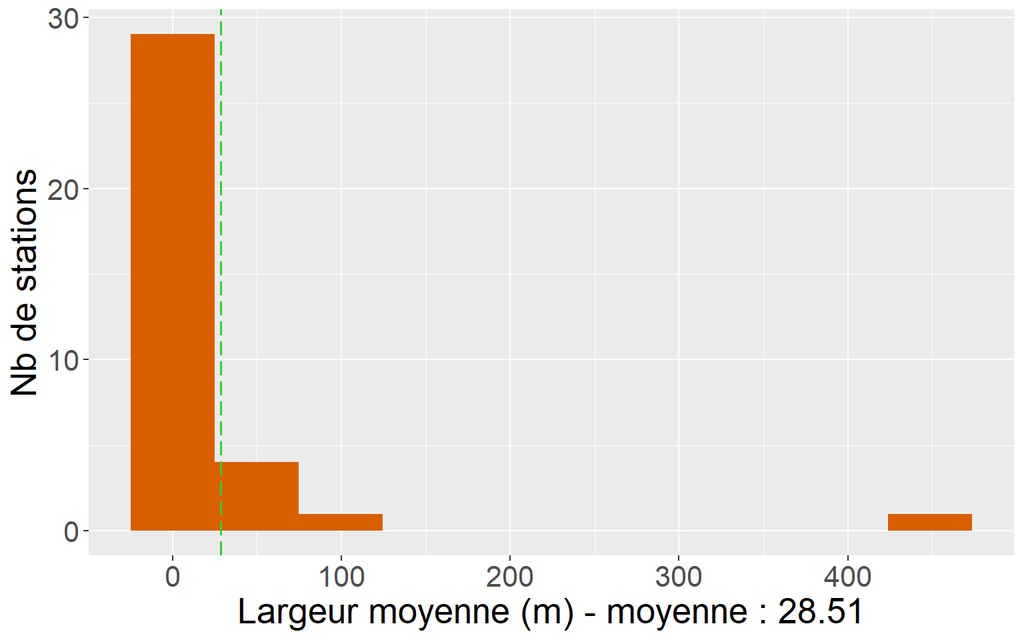

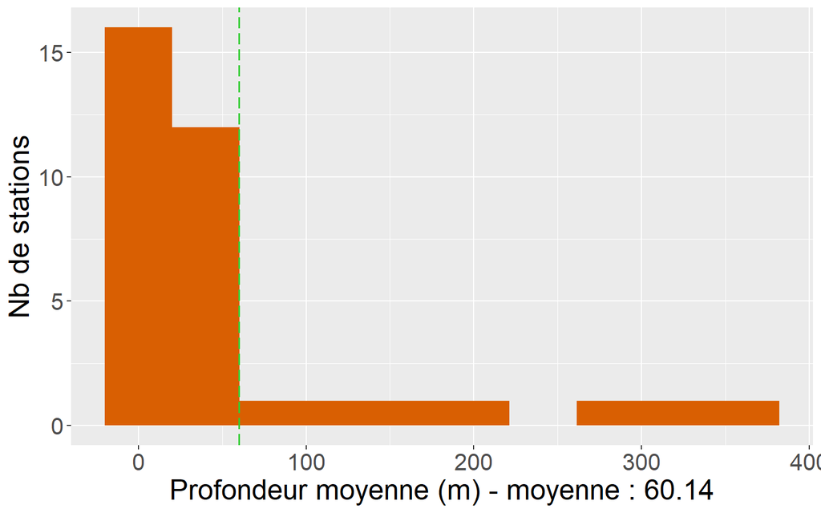

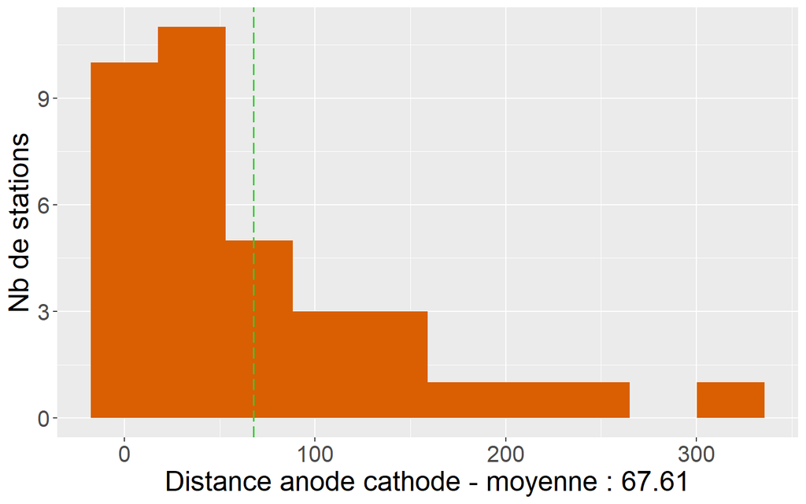

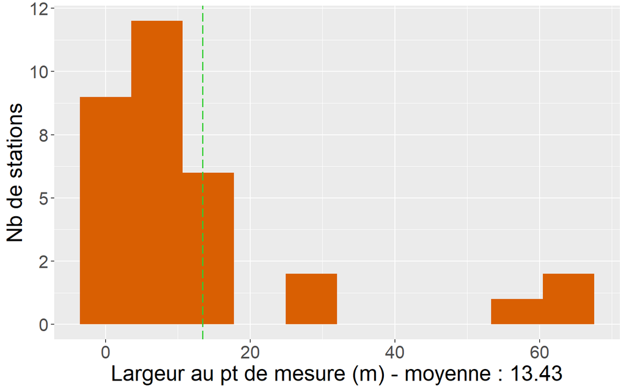

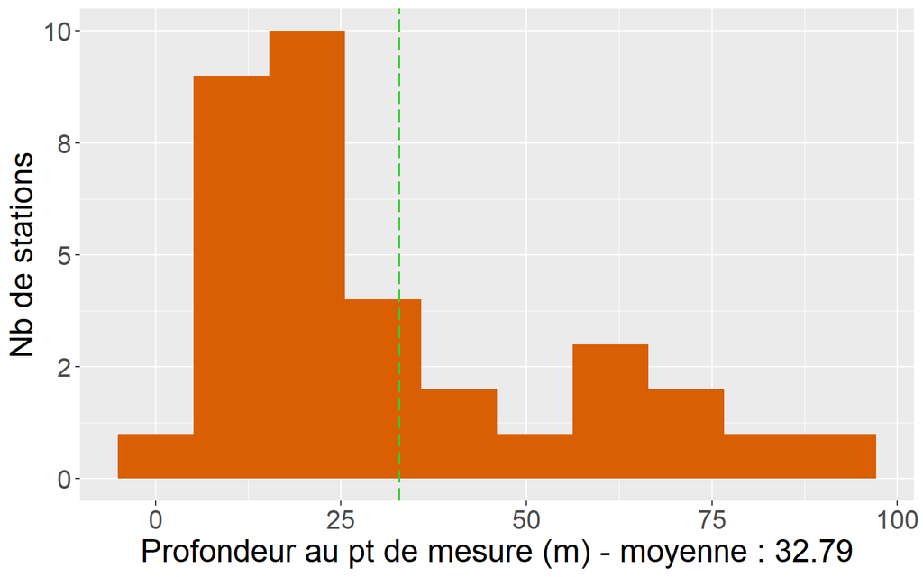

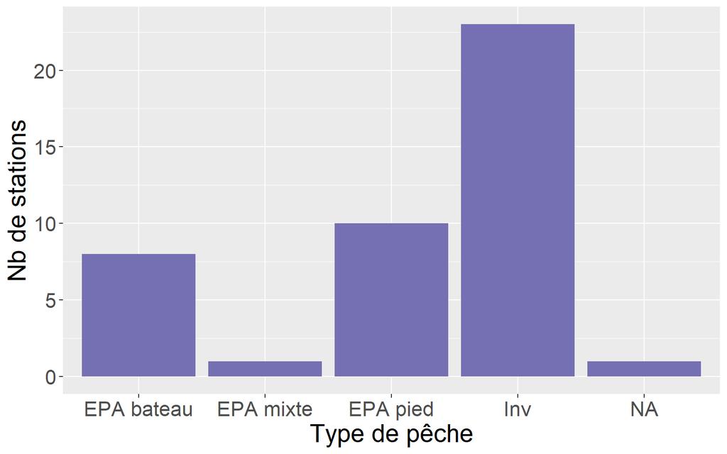

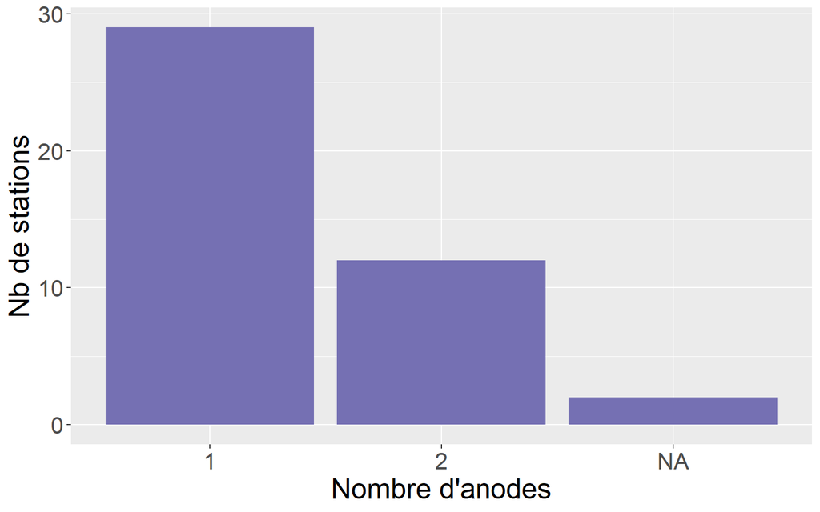

## 2.2 Le milieu au moment des opérations

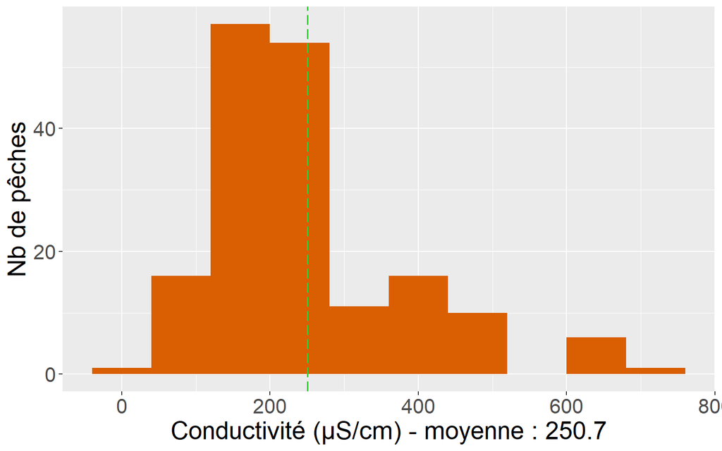

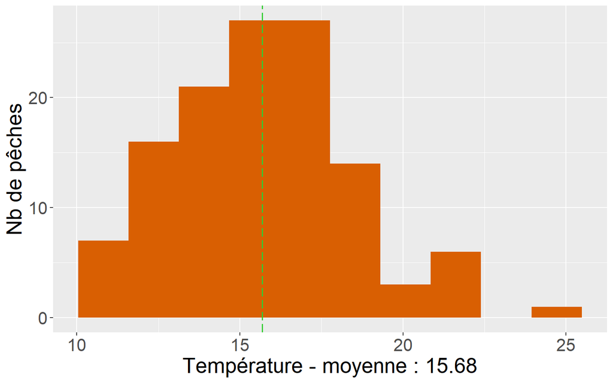

## 2.3 Les opérations

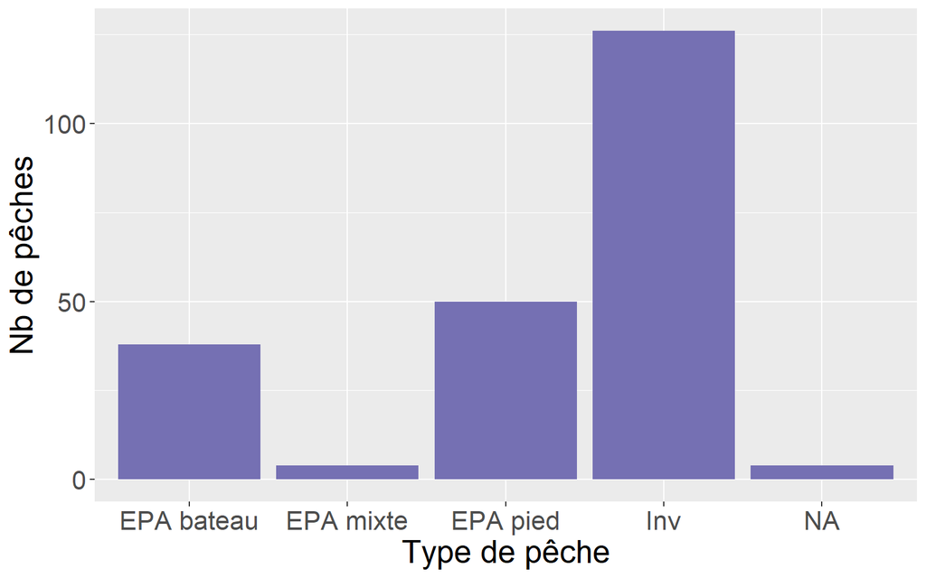

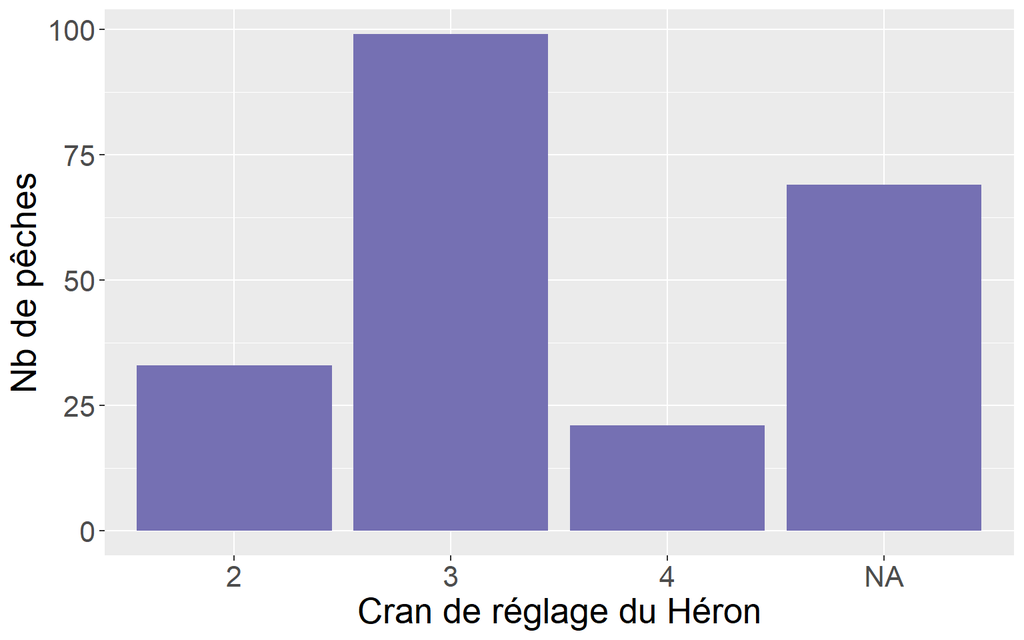

## 2.4 Interaction opération x milieu

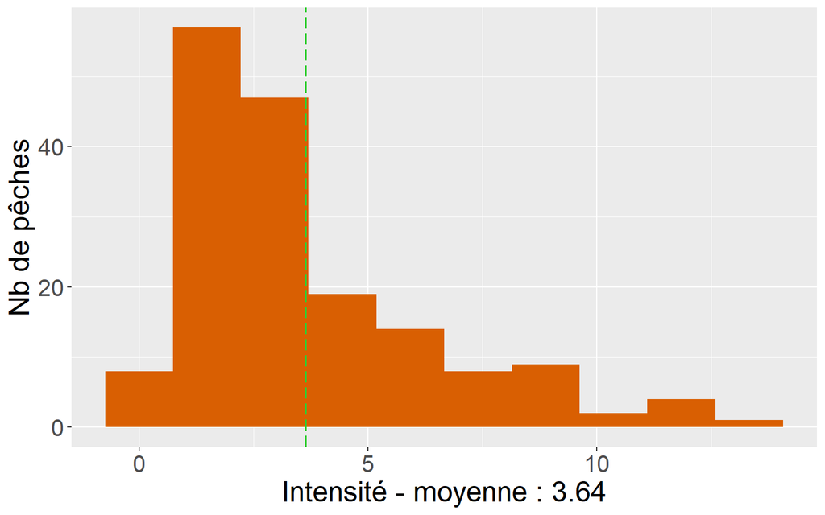

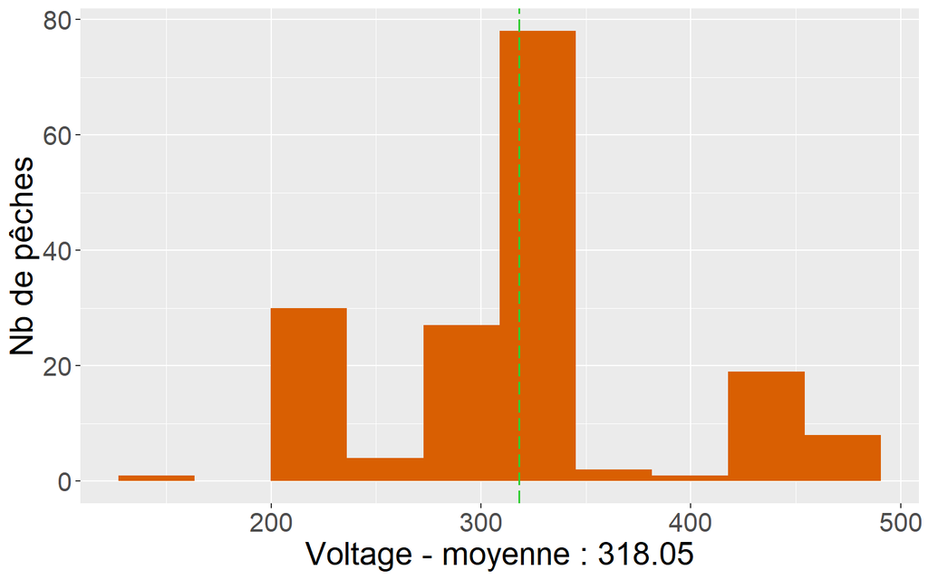

[figure not shown]

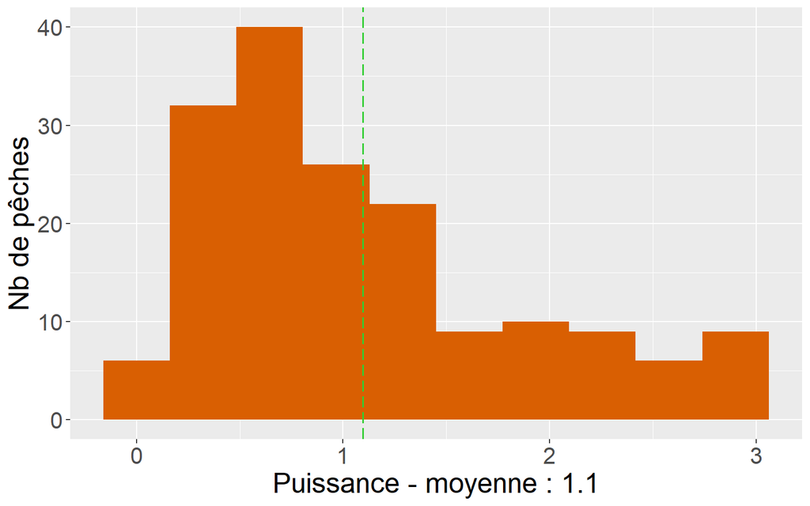

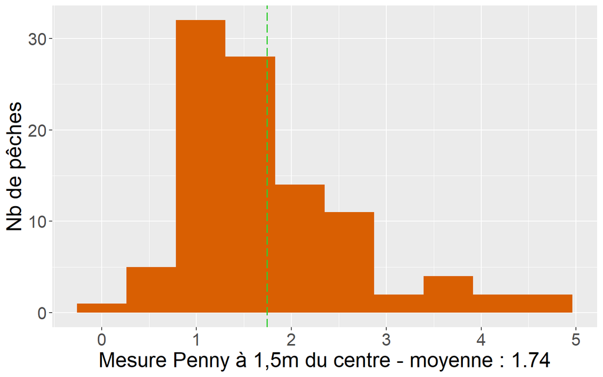

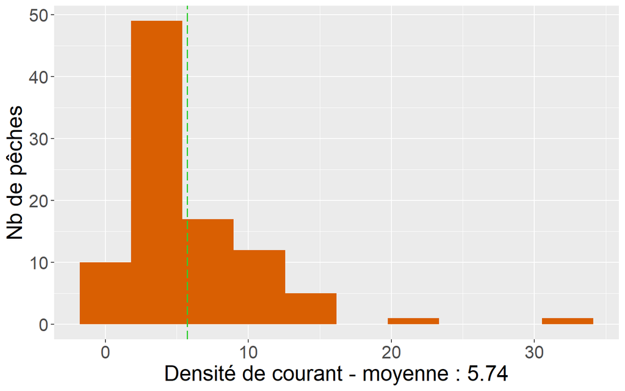

# 3 Lien entre les variables

## 3.1 Corrélations

### 3.1.1 Vue d’ensemble

On peut s’interroger sur les liens entre les variables. Certains sont évidents. Par exemple la puissance ($P$, exprimée en Watts)est le produit du voltage ($U$, en volts) et de l’intensité ($I$, en ampères) :

$P(W)=U(V)\cdot I(A)$

Il ne serait donc pas surprenant que la puissance ait tendance à augmenter quand le voltage et l’intensité augmentent.

On peut aussi penser qu’il y a un lien entre les propriétés électriques du milieu (sa conductivité) et les réglages du matériel pour obtenir l’effet souhaité sur les poissons.

Pour y voir plus clair, il est possible de visualiser les corrélations entre les couples de variables.

Les représentations graphiques ci-dessous indiquent :

- Sous la diagonale, les coefficients de corrélation
- Au-dessus de la diagonale, les nuages de points résumés par des ellipses.

Pour l’interprétation :

- Plus l’ellipse est de forme allongée, plus le lien entre les deux variables est fort.
- Plus le coefficient de corrélation est proche de 1 (corrélation positive) ou de -1 (corrélation négative), plus le lien entre les deux variables est fort.
- La couleur bleue indique des corrélations positives (quand la première variable augmente, la seconde augmente également) et le rouge les corrélations négatives (relation inverse).
- Les croix indiquent les relations statistiquement non significatives au seuil de 5%.

> NB : Comme les distributions ne sont pas toutes “gaussiennes”, on emploie ici la corrélation de Spearman.

Sur l’ensemble des données on obtient :

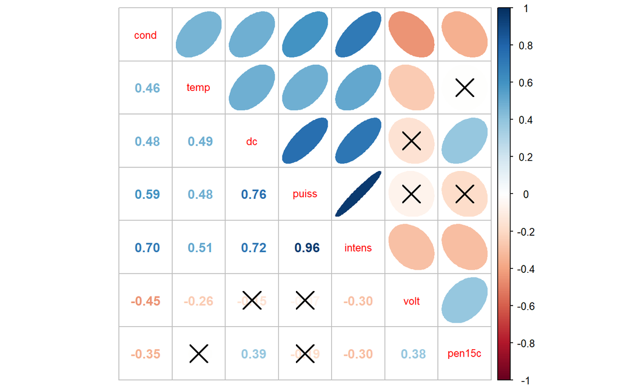

Lecture : Quand la température de l’eau est élevée, les paramètres de conductivité, puissance et intensité tendent à être élevés (corrélations positives et significatives) tandis que le voltage est plutôt faible (corrélation négative). Le voltage et la mesure Penny tendent à varier dans le même sens (corrélation positive significative).

Pour évaluer la constance des relations, on peut les comparer en subdivisant le jeu de données.

#### 3.1.1.1 Comparaison entre années

Les graphiques sont très semblables d’une année sur l’autre (non présenté ici).

#### 3.1.1.2 Comparaison selon le nombre d’anodes

Une anode

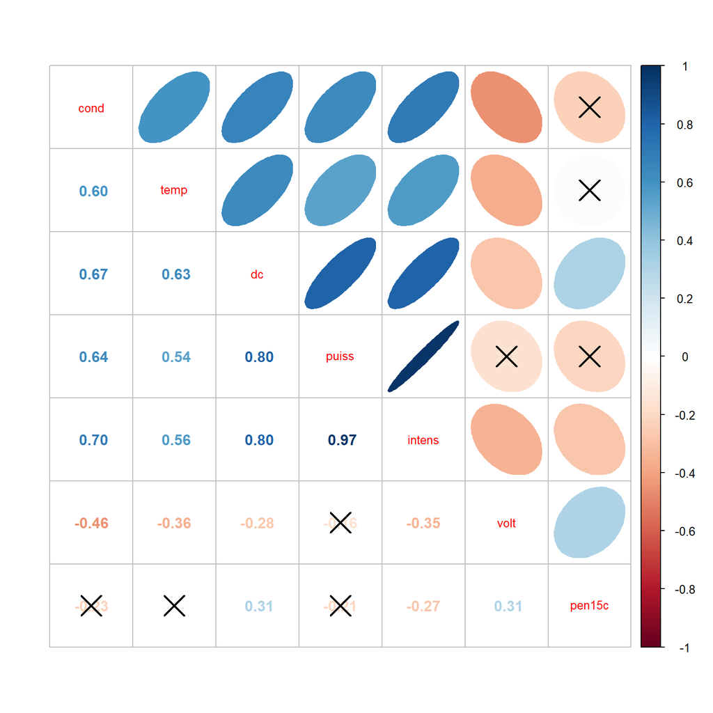

Le schéma pour une anode est pratiquement identique au schéma général.

Deux anodes

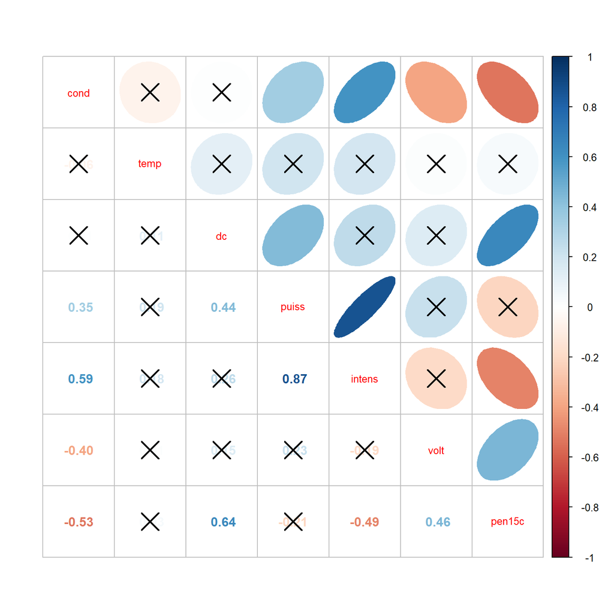

Au sein des pêches à deux anodes, il est notable que la température n’est plus liée à aucun autre paramètre. On retrouve bien le groupe conductivité - intensité - puissance corrélées positivement et un autre groupe Penny - voltage. La mesure Penny à 1,5m est toujours corrélée positivement au voltage (cas génaral) mais négativement à la conductivité (interprétation ?).

#### 3.1.1.3 Comparaison selon le cran

Cran 2

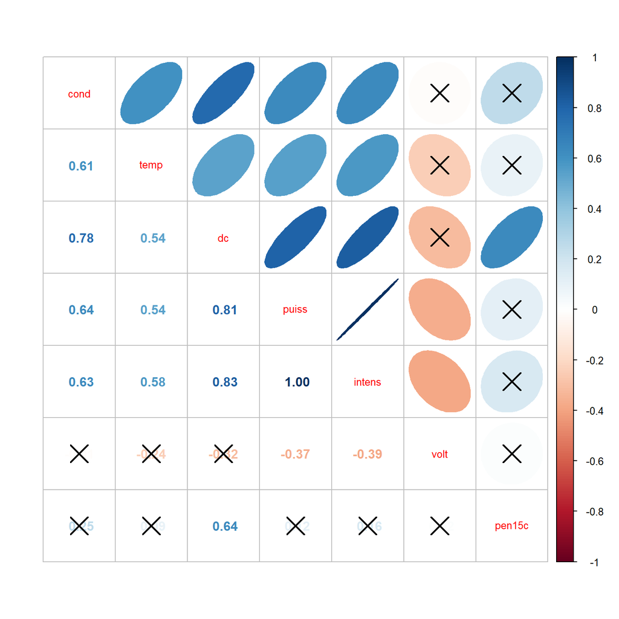

Cran 4

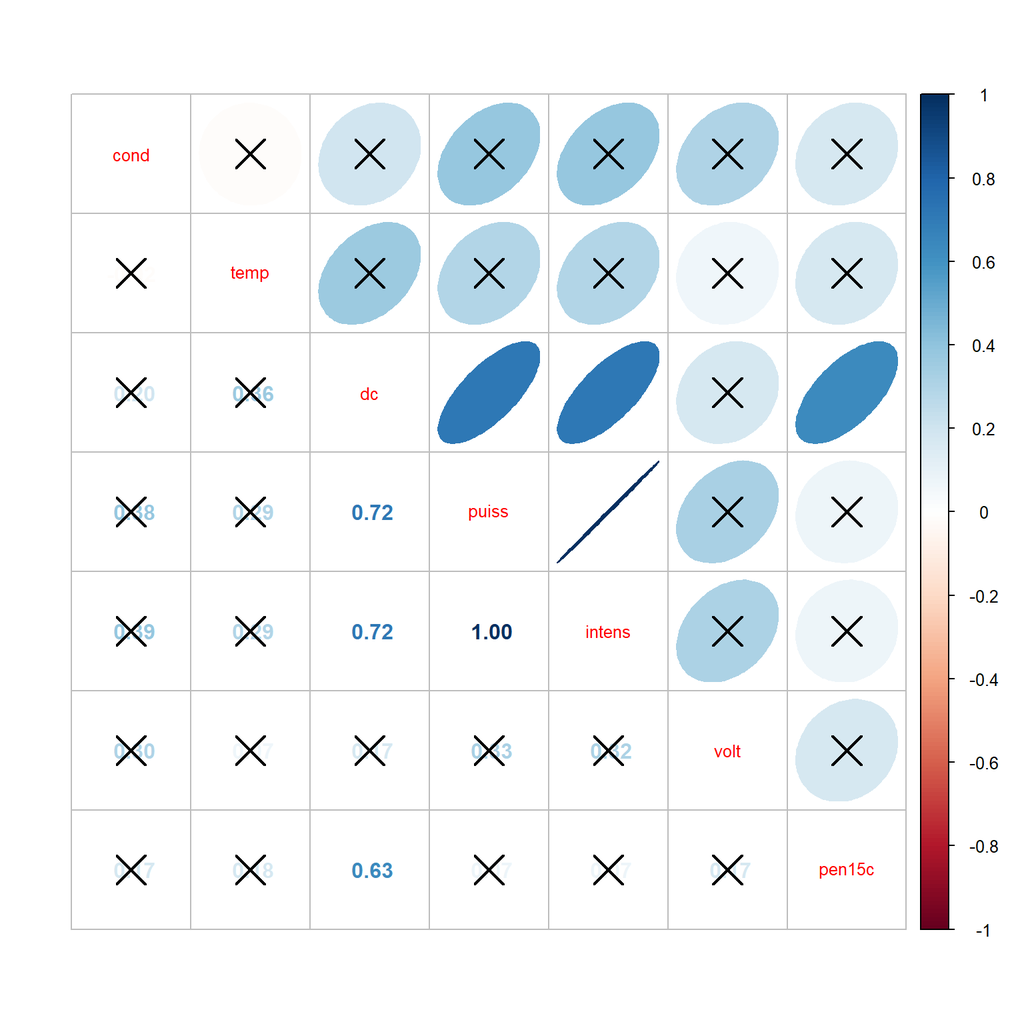

Cran 3

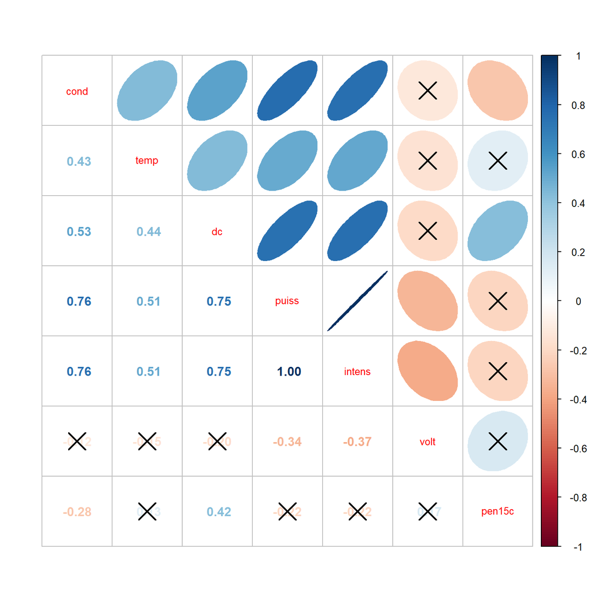

Au cran 3, qui est le plus commun, les sens de corrélation (couleur des ellipses) sont cohérents avec le schéma général mais il avec moins de paires significatives.

#### 3.1.1.4 Comparaison selon la méthode de pêche

EPA Bateau

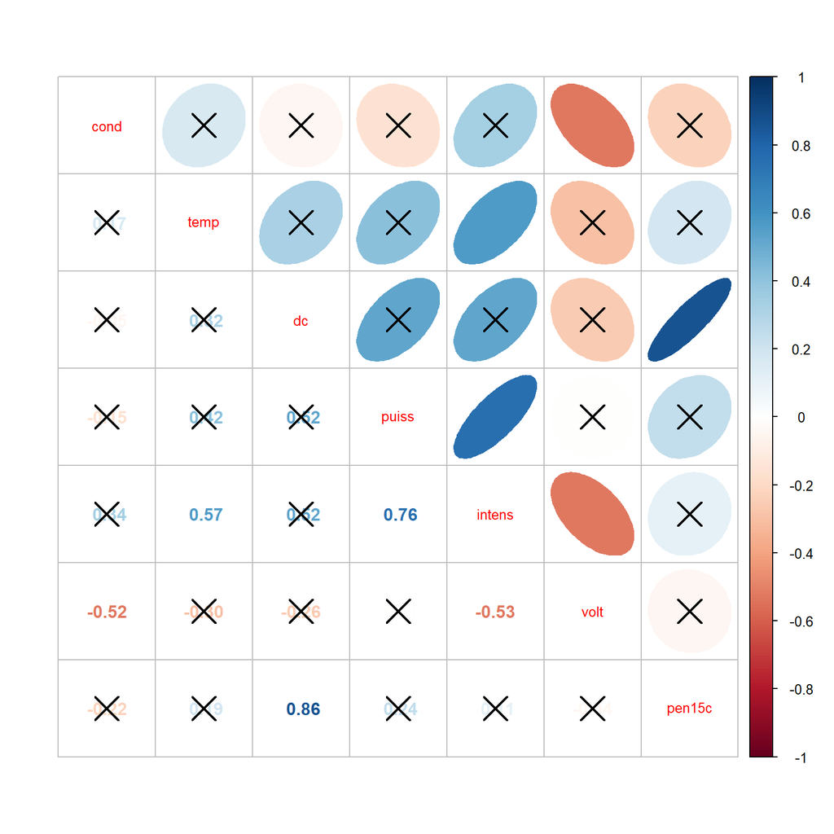

EPA à pieds

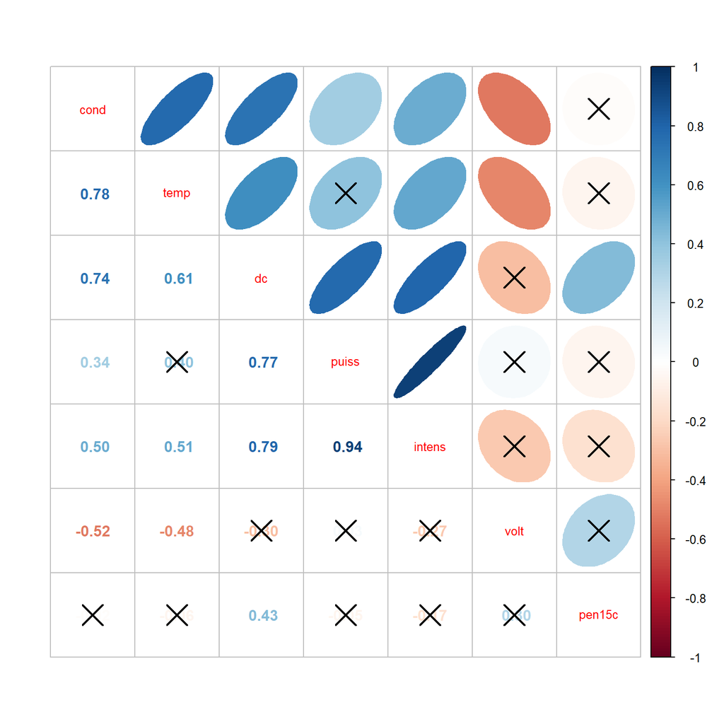

Inventaire

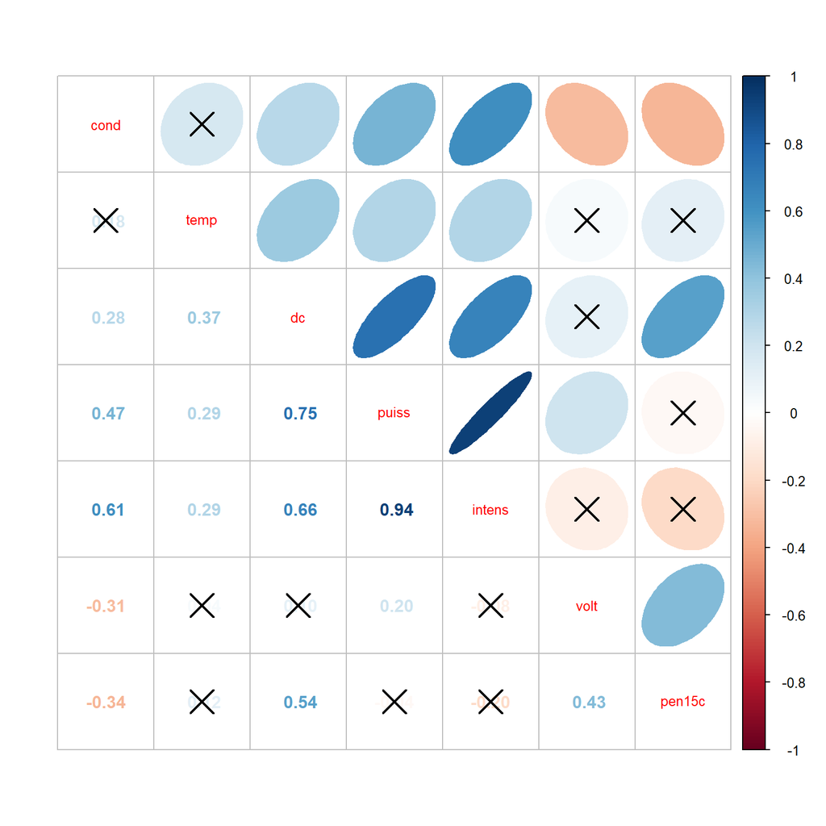

Pour les pêches d’inventaire, on retrouve à peu près le schéma général mais les corrélations sont plus faibles. La relation puissance - voltage, négative dans le cas général, est ici positive mais avec une faible corrélation.

### 3.1.2 Relation Intensité - Conductivité

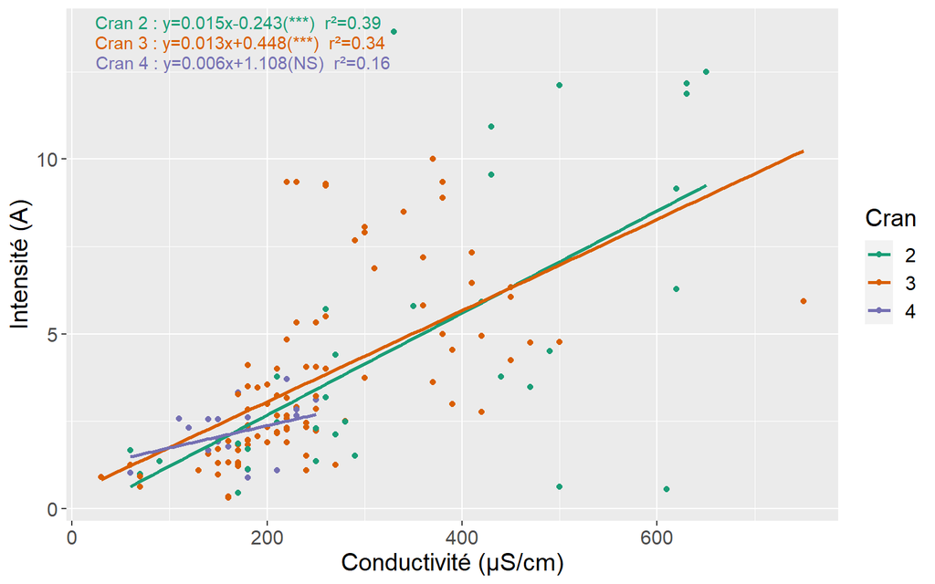

La relation intensité - conductivité est nette. Elle est très significative pour les crans 2 et 3, mais non significative pour le cran 4.

### 3.1.3 Relation Penny - Conductivité

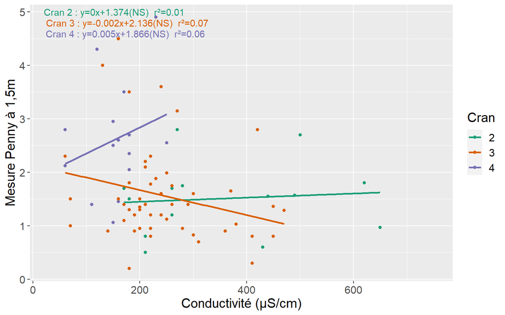

Rien de bien net ne se dégage ici (relations non significatives).

### 3.1.4 Relation Densité de courant - Conductivité

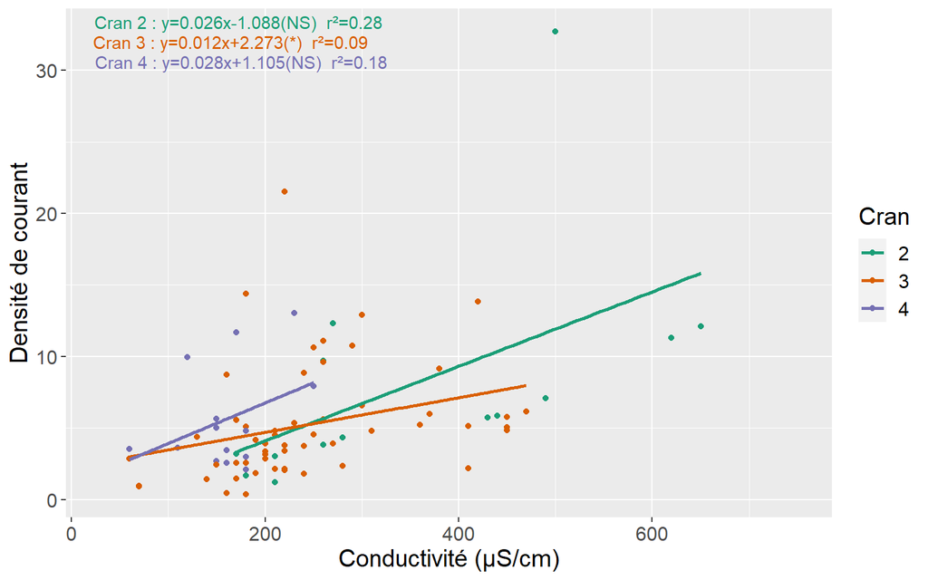

La seule relation significative est sur le cran 3. Il y a un lien mais qui est faible.